# Global Rice Production Analysis

Hari Prasannaa Thangavel Ravi, Jin Hyuk Son, Pranjal S. Wakpaijan

2024-10-21

### **Abstract**

Rice production is vital for global food security and sustainable agriculture. This research project, titled “Global Rice Production Analysis,” aims to explore the foundational stages of data-driven research in this context. Using the dataset “Explore Data on Agricultural Production,” which comprises about 13,500 rows and 40 columns. This study systematically examines key factors influencing rice yield, including land use efficiency, production per capita, import and export dynamics, waste generation, and domestic supply. The study begins with cleaning the dataset, addressing missing values and outliers, followed by examining data distribution and interrelationships between variables. The project formulates and answers three SMART questions, employing exploratory data analysis (EDA) to visualize the results. Various statistical tests were conducted to validate these findings. This study not only addresses practical challenges in rice cultivation but also provides insights to refine agricultural strategies, optimize resource allocation, and promote sustainable practices. The findings aim to assist rice producers in enhancing yield predictions and contribute to strengthening global food security.

### **Introduction**

Rice is a staple food for over half of the global population, making its production essential for food security worldwide. As global demand for rice continues to rise due to population growth and evolving dietary habits, understanding the dynamics of rice production, trade, and sustainability becomes increasingly vital. Sustainable agricultural practices not only aim to meet current food needs but also ensure the preservation of resources for future generations.

This research project, titled “Global Rice Production Analysis,” seeks to explore the foundational stages of data-driven research within the context of rice production. By leveraging extensive datasets, this study investigates key factors influencing rice yield and provides insights that can inform agricultural strategies.

Utilizing the dataset “Explore Data on Agricultural Production,” which comprises approximately 13,500 rows and 40 columns, this research focuses on essential aspects of rice production and trade. The study addresses three research questions.

To ensure the reliability of the findings, the study begins with data cleaning, addressing issues such as missing values and outliers, followed by an examination of data distribution and interrelationships among key variables. By employing exploratory data analysis (EDA) and various statistical tests, this research not only addresses practical challenges faced by rice producers but also aims to enhance yield predictions.

Ultimately, the insights gained from this study will refine agricultural strategies, optimize resource allocation, and promote sustainable practices, contributing to the broader goal of strengthening global food security.

```r
library(ezids)
library(tidyverse)
library(zoo)
library(ggplot2)
library(patchwork)
library(countrycode)
library(scales)
library(reshape2)
```

```r
rice_df <- read.csv("Rice Production Data.csv")
```

### **Data Description**

Of the 36 variables included in the dataset, we will be using 9 variables in our project: Country, Year, Production(t), Population, Land Use, Import(t), Export(t), Domestic Supply(t), and Supply Chain Waste(t). The names of the variables were modified for better comprehensibility.

Displaying the first few observations:

```r
rice_df_clean <- rice_df %>%
  select(Country, Year, Population,
         Production..t., Land.Use..ha.,
         Imports..t., Exports..t.,
         Domestic.supply..t., Supply.chain.waste..t.) %>%
  rename("Production" = "Production..t.",
         "Land_Use" = "Land.Use..ha.",
         "Imports(t)" = "Imports..t.",
         "Exports(t)" = "Exports..t.",
         "Domestic_Supply(t)" = "Domestic.supply..t.",
         "Supply_Chain_Waste(t)" = "Supply.chain.waste..t.")

xkabledplyhead(rice_df_clean, 5, title="Rice Production")
```

Rice Production

| Country | Year | Population | Production | Land_Use | Imports(t) | Exports(t) | Domestic_Supply(t) | Supply_Chain_Waste(t) |
| --- | --- | --- | --- | --- | --- | --- | --- | --- |
| Afghanistan | 1961 | 8790140 | 319000 | 210000 | 0 | NA | 213000 | 15000 |
| Afghanistan | 1962 | 8969055 | 319000 | 210000 | 0 | NA | 213000 | 15000 |
| Afghanistan | 1963 | 9157463 | 319000 | 210000 | 0 | NA | 213000 | 15000 |
| Afghanistan | 1964 | 9355510 | 380000 | 220000 | 0 | NA | 253000 | 18000 |
| Afghanistan | 1965 | 9565154 | 380000 | 220000 | 0 | NA | 253000 | 18000 |

Displaying the summary of the dataset

```r
summary(rice_df_clean)
```

```
##    Country               Year        Population         Production
##  Length:13503       Min.   :1961   Min.   :1.22e+04   Min.   :0.00e+00
##  Class :character   1st Qu.:1977   1st Qu.:2.39e+06   1st Qu.:2.41e+04
##  Mode  :character   Median :1993   Median :1.02e+07   Median :3.04e+05
##                     Mean   :1992   Mean   :1.71e+08   Mean   :2.09e+07
##                     3rd Qu.:2008   3rd Qu.:5.37e+07   3rd Qu.:3.18e+06
##                     Max.   :2022   Max.   :7.98e+09   Max.   :7.89e+08
##                                    NA's   :34         NA's   :3375
##     Land_Use          Imports(t)         Exports(t)       Domestic_Supply(t)
##  Min.   :0.00e+00   Min.   :       0   Min.   :       0   Min.   :   -72000
##  1st Qu.:1.10e+04   1st Qu.:    6000   1st Qu.:       0   1st Qu.:    22000
##  Median :1.12e+05   Median :   45000   Median :    2000   Median :   142000
##  Mean   :6.01e+06   Mean   :  822672   Mean   :  850699   Mean   : 12570499
##  3rd Qu.:9.93e+05   3rd Qu.:  347000   3rd Qu.:  112000   3rd Qu.:  1588000
##  Max.   :1.66e+08   Max.   :82227000   Max.   :76530000   Max.   :761276000
##  NA's   :3405       NA's   :759        NA's   :1721       NA's   :753
##  Supply_Chain_Waste(t)
##  Min.   :       0
##  1st Qu.:    1000
##  Median :    7000
##  Mean   :  778451
##  3rd Qu.:  109000
##  Max.   :33801000
##  NA's   :3094
```

### **Data Cleaning**

The initial step in our analysis involved cleaning the dataset, which contained data for approximately 190 countries, along with continent-level data, European Union data, and some countries combined into groups by the FAO, all sourced from Our World in Data. We observed significant discrepancies between the mean and median values across all columns, primarily due to the aggregation of various countries into these groups. Such differences can lead to skewed results, prompting us to retain only the rows containing individual country data.

To address missing data, we employed different imputation methods tailored to the type of variable. For population data, we calculated the average population growth rate for each country over the selected years and used this average to replace any missing values. This approach ensured that population estimates remained consistent with historical growth trends. We used linear interpolation to impute missing values in other columns.

```r
rice_df_clean <- rice_df_clean %>%
  filter(Year >= 1980) %>%
  mutate(
    area_type = case_when(
      str_detect(Country, "FAO") ~ "Region",
      str_detect(Country, "(?i)countries") ~ "Region",
      str_detect(Country, "European Union") ~ "Region",
      str_detect(Country, "World") ~ "World",
      Country %in% c(
        "North America",
        "South America",
        "Asia",
        "Africa",
        "Europe",
        "Oceania",
        "Antarctica",
        "Melanesia",
        "Micronesia"
      ) ~ "Continent",
      TRUE ~ "Country"
    )
  ) %>%
  filter(area_type == "Country" | area_type == "World")
```

```r
#Select columns of interest and clean NAs
trade_df <- rice_df_clean %>%
  filter(Year >= 1980 & Year < 2022) #2021 the most recent data

#to check the number of missing values for each column
missing_values <- colSums(is.na(trade_df))
missing_values
```

```
##               Country                  Year            Population
##                     0                     0                     2
##            Production              Land_Use            Imports(t)
##                  2333                  2344                   380
##            Exports(t)    Domestic_Supply(t) Supply_Chain_Waste(t)
##                  1037                   376                  2135
##             area_type
##                     0
```

```r
#data cleaning
columns_to_check <- c("Production", "Imports(t)", "Exports(t)", "Land_Use", "Domestic_Supply(t)", "Supply_Chain_Waste(t)")
trade_df_cleaned <- trade_df

for (col in columns_to_check) {
  trade_df_cleaned <- trade_df_cleaned %>%
    mutate(!!col := if_else(
      Country %in% (
        trade_df_cleaned %>%
          group_by(Country) %>%
          summarize(
            all_zero_or_na = all(is.na(.data[[col]]) | .data[[col]] == 0),
            .groups = 'drop'
          ) %>%
          filter(all_zero_or_na) %>%
          pull(Country)
      ),
      0,
      .data[[col]]
    ))
}

# Calculate growth rates
population_data <- trade_df_cleaned %>%
  mutate(GrowthRate = (Population - lag(Population)) / lag(Population))

#calculating mean growth rate
average_growth_rate <- mean(population_data$GrowthRate, na.rm = TRUE)

#function to impute data based on calculated growth rate
impute_population <- function(data, avg_growth) {
  for (i in 1:nrow(data)) {
    if (is.na(data$Population[i])) {
      previous_population <- data$Population[i - 1]  # Last known population
      data$Population[i] <- previous_population * (1 + avg_growth)  # Impute using growth rate
    }
  }
  return(data)
}

# Impute missing values
population_data <- impute_population(population_data, average_growth_rate)

#group by data to mutate the Import and Export for specific countries
population_data <- population_data %>%
  group_by(Country) %>%
  mutate(`Imports(t)` = na.approx(`Imports(t)`, na.rm = FALSE),
         `Exports(t)` = na.approx(`Exports(t)`, na.rm = FALSE),
         `Land_Use` = na.approx(`Land_Use`, na.rm = FALSE),
         `Domestic_Supply(t)` = na.approx(`Domestic_Supply(t)`, na.rm = FALSE),
         `Supply_Chain_Waste(t)` = na.approx(`Supply_Chain_Waste(t)`, na.rm = FALSE)) %>%
  ungroup()

#fill in missing values in the Import and Export columns using interpolation
population_data$`Imports(t)` <- na.approx(population_data$`Imports(t)`, na.rm = FALSE)
population_data$`Exports(t)` <- na.approx(population_data$`Exports(t)`, na.rm = FALSE)
population_data$`Land_Use` <- na.approx(population_data$`Land_Use`, na.rm = FALSE)
population_data$`Domestic_Supply(t)` <- na.approx(population_data$`Domestic_Supply(t)`, na.rm = FALSE)
population_data$`Supply_Chain_Waste(t)` <- na.approx(population_data$`Supply_Chain_Waste(t)`, na.rm = FALSE)

final_trade_df <- population_data %>%
  filter(!is.na(`Exports(t)`)) %>%
  select(-GrowthRate)
```

### **Exploratory Data Analysis(EDA)**

We began by plotting histograms to examine the distribution of each column. The graphs revealed a right skew, prompting us to perform a log transformation to enhance symmetry. Following this, we plotted various columns against the production, our independent variable, to gain insights from the visualizations.

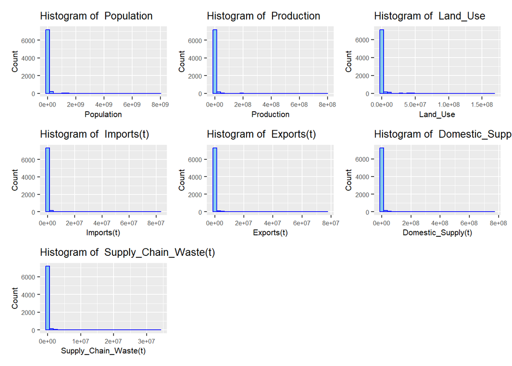

```r
selected_columns = c(
  "Population",
  "Production",
  "Land_Use",
  "Imports(t)",
  "Exports(t)",
  "Domestic_Supply(t)",
  "Supply_Chain_Waste(t)"
)

#to see the distribution of each column
plots <- list()
for (col in selected_columns) {
  if (is.numeric(final_trade_df[[col]])) {
    p <- ggplot(final_trade_df, aes(x = .data[[col]])) +
      geom_histogram(bins = 30,
                     color = "blue",
                     fill = "skyblue") +
      labs(title = paste("Histogram of ", col),
           x = col,
           y = "Count") +
      theme(
        plot.title = element_text(size = 10),
        axis.title.x = element_text(size = 8),
        axis.title.y = element_text(size = 8),
        axis.text = element_text(size = 6)
      )
    plots[[col]] <- p
  }
}
combined_plot <- wrap_plots(plots, ncol = 3)
print(combined_plot)
```

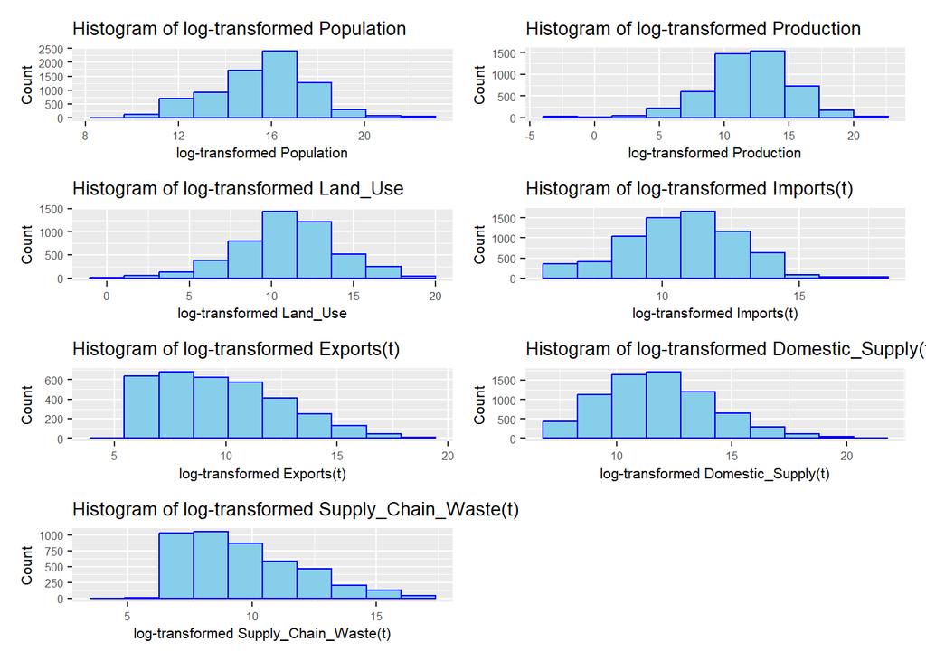

```r
#since each distribution is skewed performing log transformation to improve the symmetry
copied <- final_trade_df
plots <- list()

for (col in selected_columns) {
  if (is.numeric(copied[[col]])) {
    # Filter out non-positive values
    filtered_data <- copied %>% filter(!!sym(col) > 0)

    # Create a new log-transformed column
    filtered_data <- filtered_data %>%
      mutate(!!sym(paste0("log_", col)) := log(!!sym(col)))

    # Create histogram for the log-transformed variable
    p <- ggplot(filtered_data, aes(x = .data[[paste0("log_", col)]])) +
      geom_histogram(bins = 10,
                     color = "blue",
                     fill = "skyblue") +
      labs(
        title = paste("Histogram of log-transformed", col),
        x = paste("log-transformed ", col, sep = ""),
        y = "Count"
      ) +
      theme(
        plot.title = element_text(size = 10),
        axis.title.x = element_text(size = 8),
        axis.title.y = element_text(size = 8),
        axis.text = element_text(size = 6)
      )

    plots[[col]] <- p
  }
}

# Combine the plots
combined_plot <- wrap_plots(plots, ncol = 2)
print(combined_plot)
```

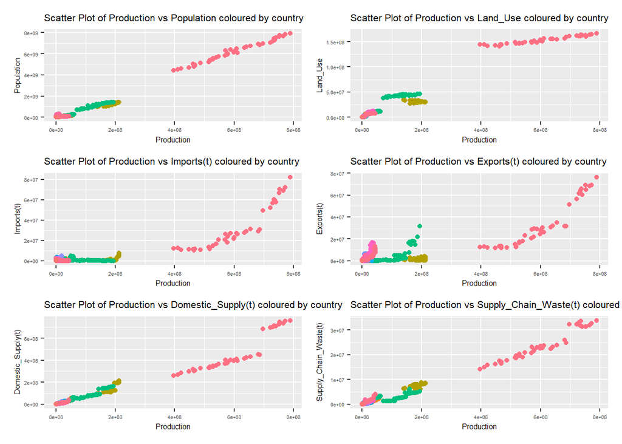

```r
#scatter plot with production vs other parameters colured by country
plots <- list()

# Loop through each parameter and create a scatter plot
for (col in selected_columns) {
  if (col != "Production") {
    p <- ggplot(final_trade_df, aes(
      x = .data[["Production"]],
      y = .data[[col]],
      color = .data[["Country"]]
    )) +
      geom_point() +
      labs(
        title = paste("Scatter Plot of Production vs", col, "coloured by country"),
        x = "Production",
        y = col
      ) +
      theme(
        legend.position = "none",
        plot.title = element_text(size = 8),
        axis.title.x = element_text(size = 6),
        axis.title.y = element_text(size = 6),
        axis.text = element_text(size = 4)
      )
    theme_minimal()

    plots[[col]] <- p
  }
}

#Combine all plots into a single layout
combined_plot <- wrap_plots(plots, ncol = 2)
print(combined_plot)
```

The production versus population scatterplot showed a general upward trend, indicating a positive correlation. However, the data points were widely dispersed, reflecting variability in how the population scales with higher production levels. While regions with higher production levels tend to have larger populations, notable exceptions exist. Most data points in the lower range suggest that most values fall within this segment. Similarly, a positive correlation was observed between production and land use, although this relationship was less strong and consistent. At higher production values, the increased scatter suggests that land use can vary considerably even for similar production levels. This variability may imply that factors beyond production influence land use, or that production efficiency—producing more with less land—differs across contexts.

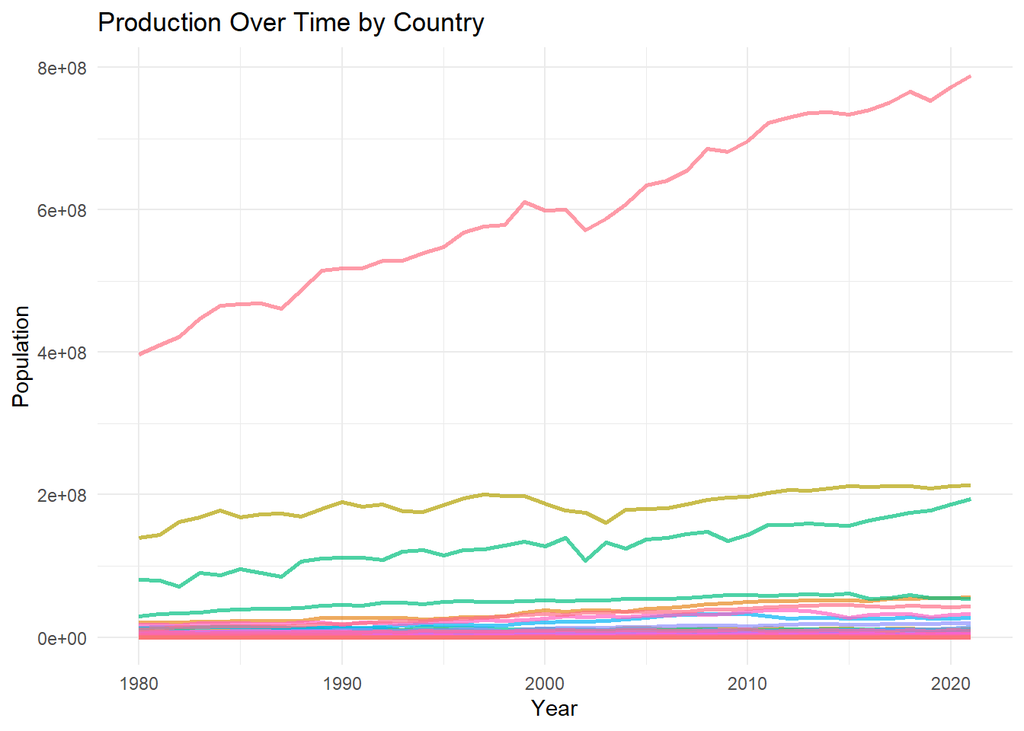

```r
#Production over time for each country
ggplot(final_trade_df, aes(x = Year, y = Production, color = Country)) +
  geom_line(alpha = 0.7, size = 1) +
  labs(title = "Production Over Time by Country", x = "Year", y = "Population") + theme_minimal() +
  theme(legend.position = "none")
```

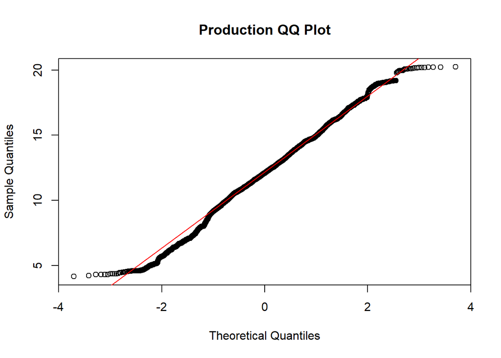

```r
#qqplot
log_df <- final_trade_df %>%
  filter(Production > 0) %>%
  mutate(Production = log(Production))

iqr <- IQR(log_df$Production)
lower_bound <- quantile(log_df$Production, 0.25) - 1.5 * iqr
upper_bound <- quantile(log_df$Production, 0.75) + 1.5 * iqr

no_outliers <- log_df %>%
  filter(Production >= lower_bound, Production <= upper_bound)

qqnorm(no_outliers$Production, main = "Production QQ Plot")
qqline(no_outliers$Production, col = "red")
```

A QQ plot was generated for production, indicating that it approximately follows a normal distribution for most of the sample, with slight deviations observed in the tails.

### **Research Question 1**

Was there a notable change in the global rice trade trend in the last 20 years, specifically in terms of export percentages and import dependency? How did this change impact different regions and countries of varying population sizes, and what does it reveal about the changes in rice production and trade?

#### **Methods**

To conduct analysis on the research question, we have made the following additions to the dataset.

- **Percent Exported**: We have divided the export volume by production to analyze the growth of the global rice market.

```r
#Exported percentage
final_trade_df <- final_trade_df %>%
  mutate(`Percent Exported` = `Exports(t)` / Production * 100) %>%
  filter(!is.infinite(`Percent Exported`) & !is.na(`Percent Exported`))
```

- **Import Dependency Ratio (IDR):** The Food and Agriculture Organization of the United Nations (2012) defines IDR as imports x 100/(production + imports - exports) (pp.359). A higher IDR indicates a greater reliance on imports for rice. We have categorized IDR as follows:
  - Very High: 50 or greater
  - High: 40-49
  - Medium: 30-39
  - Low: 20-29
  - Very Low: Below 20

```r
#Import dependency ratio
final_trade_df <- final_trade_df %>%
  mutate(IDR = `Imports(t)` * 100 /
           (Production + `Imports(t)` - `Exports(t)`)) %>%
  filter(!is.infinite(IDR) & !is.na(IDR))

#Giving tags for IDR and Population
##IDR
final_trade_df <- final_trade_df %>%
  mutate(`IDR Category` = case_when(
    IDR >= 50 ~ "Very High",
    IDR >= 40 ~ "High",
    IDR >= 30 ~ "Medium",
    IDR >= 20 ~ "Low",
    TRUE ~ "Very Low"
  ))
final_trade_df$`IDR Category` <-
  factor(final_trade_df$`IDR Category`,
         levels = c("Very Low", "Low",
                    "Medium", "High", "Very High"))
```

```r
##Population
final_trade_df <- final_trade_df %>%
  mutate(`Population Category` = case_when(
    Population < 10000000 ~ "Small",
    Population < 50000000 ~ "Medium",
    Population < 100000000 ~ "Large",
    TRUE ~ "Very Large"
  ))
final_trade_df$`Population Category` <-
  factor(final_trade_df$`Population Category`,
         levels = c("Small", "Medium", "Large"))
```

- **Region:** The continent to which each country belongs has been identified using the “countrycode” package.

```r
#Add region for each country
final_trade_df$Continent <- countrycode(sourcevar =
                                    final_trade_df$Country,
                                  origin = "country.name",
                                  destination = "continent")
final_trade_df$Continent <- as.factor(final_trade_df$Continent)
```

- **Log import:** Since the import variable is right-skewed, we applied a logarithmic transformation to achieve normality for hypothesis testing.

```r
final_trade_df <- final_trade_df %>%
  mutate(log_import = log(`Imports(t)` + 1))
```

Displaying the summary of the processed data:

```r
summary(final_trade_df)
```

```
##    Country               Year        Population         Production
##  Length:4846        Min.   :1980   Min.   :6.68e+04   Min.   :0.00e+00
##  Class :character   1st Qu.:1990   1st Qu.:4.84e+06   1st Qu.:2.40e+04
##  Mode  :character   Median :2001   Median :1.21e+07   Median :1.73e+05
##                     Mean   :2001   Mean   :1.03e+08   Mean   :1.04e+07
##                     3rd Qu.:2011   3rd Qu.:3.67e+07   3rd Qu.:1.39e+06
##                     Max.   :2021   Max.   :7.91e+09   Max.   :7.89e+08
##     Land_Use          Imports(t)         Exports(t)       Domestic_Supply(t)
##  Min.   :0.00e+00   Min.   :       0   Min.   :       0   Min.   :   -72000
##  1st Qu.:9.56e+03   1st Qu.:   13000   1st Qu.:       0   1st Qu.:    67250
##  Median :6.21e+04   Median :   60000   Median :    1000   Median :   273258
##  Mean   :2.65e+06   Mean   :  499765   Mean   :  565696   Mean   :  8007403
##  3rd Qu.:4.14e+05   3rd Qu.:  232000   3rd Qu.:   22000   3rd Qu.:  1399000
##  Max.   :1.66e+08   Max.   :82227000   Max.   :76530000   Max.   :761276000
##  Supply_Chain_Waste(t)  area_type         Percent Exported        IDR
##  Min.   :       0      Length:4846        Min.   :0.00e+00   Min.   :-80
##  1st Qu.:    1000      Class :character   1st Qu.:0.00e+00   1st Qu.:  3
##  Median :    7000      Mode  :character   Median :0.00e+00   Median : 25
##  Mean   :  409432                         Mean   :2.33e+05   Mean   : 38
##  3rd Qu.:   44000                         3rd Qu.:7.00e+00   3rd Qu.: 70
##  Max.   :33801000                         Max.   :1.03e+08   Max.   :459
##     IDR Category  Population Category    Continent      log_import
##  Very Low :2238   Small :2076         Africa  :1757   Min.   : 0.00
##  Low      : 347   Medium:1850         Americas:1137   1st Qu.: 9.47
##  Medium   : 285   Large : 442         Asia    :1254   Median :11.00
##  High     : 259   NA's  : 478         Europe  : 452   Mean   :10.07
##  Very High:1717                       Oceania : 165   3rd Qu.:12.35
##                                       NA's    :  81   Max.   :18.22
```

During the analysis, we will use two different statistical methods. A two-sample t-test will be conducted to compare the log means between observations from 2000s and 2010s. The chi-squared test will be used to assess the relationship between IDR and both population categories and regions.

#### **Analysis**

We began our analysis by looking at the overall import and export trend from 1980 to 2021. It was clear that there was a spike in the overall volume of rice trade near the end of 2000s.

```r
pivot_exported_per <- final_trade_df %>%
  filter(Country == "World") %>%
  select(Year, `Percent Exported`) %>%
  filter(Year >= 2005 & Year <= 2015) %>%
  pivot_wider(names_from = Year, values_from = `Percent Exported`)
pivot_exported_per
```

```
## # A tibble: 1 × 11
##   `2005` `2006` `2007` `2008` `2009` `2010` `2011` `2012` `2013` `2014` `2015`
##    <dbl>  <dbl>  <dbl>  <dbl>  <dbl>  <dbl>  <dbl>  <dbl>  <dbl>  <dbl>  <dbl>
## 1   4.81   4.99   5.31   4.58   4.61   7.36   7.85   8.42   8.38   8.93   8.76
```

When we see the trend in percentage of global rice production exported, we can clearly see there was a sudden rise, from 4.61% in 2009 to 7.36% in 2010 with continued increase. This raises the question; can we identify the 2000s and 2010s as two different phases of global rice trade trend?

**Hypothesis Test for the Two Decades**

To determine if there surely was a significant change in rice trade pattern, we have conducted the two-sample t-test between observations made in 2000s and 2010s. The log import variable was used to compare the two decades.

- Null Hypothesis: There is no significant difference in the average log import between the 2000s and 2010s.
- Alternative Hypothesis: There is a significant difference in the average log import between the 2000s and 2010s.

```r
#Divide into two decades
trade_df_2000s <- final_trade_df %>%
  filter(Year >= 2000 &
           Year < 2010 &
           area_type == "Country")

trade_df_2010s <- final_trade_df %>%
  filter(Year >= 2010 &
           Year < 2020 &
           area_type == "Country")
##T test
trade_ttest <- t.test(trade_df_2000s$log_import, trade_df_2010s$log_import)
```

The test shows that the average log import volume for 2000s was 10.0 and that of 2010s was 10.5 with p-value of 1.062^{-12} at 95 percent confidence level. With p-value lower than 0.05, we can reject the null hypothesis that there is no significant difference between the two decades.

**Chi-Squared Test of Independence for IDR**

In addition to the t-test, we have conducted the chi-squared test between IDR and both population categories and regions for each decade to observe which type of countries were impacted by the changes in global trade trend.

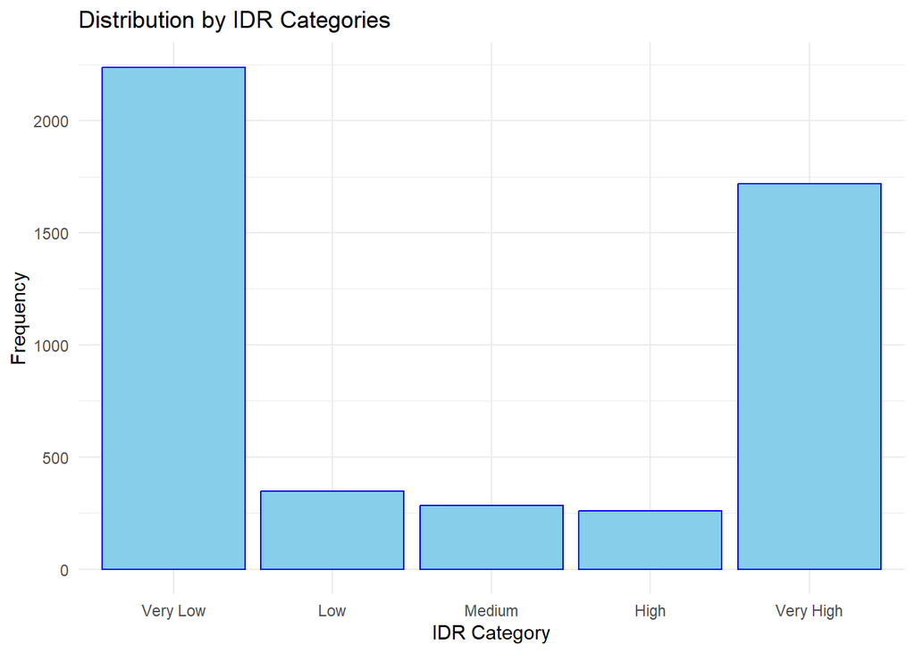

```r
#Plot a barplot of IDR categories
final_trade_df %>%
  ggplot(aes(x = `IDR Category`)) +
  geom_bar(fill = "skyblue", color = "blue" ) +
  labs(title = "Distribution by IDR Categories",
       y = "Frequency") +
  theme_minimal()
```

The distribution by IDR categories indicates that the majority of countries fall into either the very low or very high import dependency categories, suggesting a polarization in global rice trade. Most countries are either self-sufficient or are heavily reliant on imports.

- **IDR and Regions**

  We categorized countries based on their IDR and analyzed how these categories relate to the region or continent they belong to. The following are contingency tables for 2000s and 2010s.

```r
#Contingency table and Test for IDR vs Region
#2000s
IDR_Reg_2000s <- table(trade_df_2000s$Continent,
                       trade_df_2000s$`IDR Category`)
xkabledply(IDR_Reg_2000s, title = "Contingency table for IDR vs Regions in 2000s")
```

Contingency table for IDR vs Regions in 2000s

|  | Very Low | Low | Medium | High | Very High |
| --- | --- | --- | --- | --- | --- |
| Africa | 126 | 31 | 21 | 24 | 215 |
| Americas | 160 | 9 | 12 | 10 | 76 |
| Asia | 208 | 25 | 15 | 6 | 55 |
| Europe | 24 | 11 | 16 | 13 | 46 |
| Oceania | 4 | 2 | 1 | 0 | 33 |

```r
chitest_IDR_Reg_2000s = chisq.test(IDR_Reg_2000s)
#2010s
IDR_Reg_2010s <- table(trade_df_2010s$Continent,
                       trade_df_2010s$`IDR Category`)
xkabledply(IDR_Reg_2010s, title = "Contingency table for IDR vs Regions in 2010s")
```

Contingency table for IDR vs Regions in 2010s

|  | Very Low | Low | Medium | High | Very High |
| --- | --- | --- | --- | --- | --- |
| Africa | 95 | 27 | 27 | 22 | 253 |
| Americas | 132 | 21 | 12 | 4 | 96 |
| Asia | 193 | 9 | 26 | 17 | 74 |
| Europe | 13 | 12 | 17 | 10 | 58 |
| Oceania | 0 | 0 | 2 | 1 | 37 |

```r
chitest_IDR_Reg_2010s = chisq.test(IDR_Reg_2010s)
```

The p-value for test on 2000s is 1.763^{-37} and the the p-value for test on 2010s is 4.006^{-41} . The low p-values indicate an association between region and IDR category. Countries in Africa and Europe tend to be more reliant on rice imports, while countries in Asia and the Americas are more likely to be self-sufficient.

From the contingency tables, we can also observe that in the 2010s, the number of observations in the “very high” import dependency category increased across all regions, while the opposite occurred for the “very low” import dependency category.

- **IDR and Population**

```r
#Contingency table and Test for IDR vs Population Category
#2000s
IDR_Pop_2000s <- table(trade_df_2000s$`Population Category`,
                       trade_df_2000s$`IDR Category`)
xkabledply(IDR_Pop_2000s, title = "Contingency table for IDR vs Population in 2000s")
```

Contingency table for IDR vs Population in 2000s

|  | Very Low | Low | Medium | High | Very High |
| --- | --- | --- | --- | --- | --- |
| Small | 177 | 26 | 26 | 25 | 218 |
| Medium | 204 | 30 | 29 | 23 | 184 |
| Large | 58 | 15 | 5 | 3 | 22 |

```r
chitest_IDR_Pop_2000s = chisq.test(IDR_Pop_2000s)
#2010s
###Test for IDR vs Population
IDR_Pop_2010s <- table(trade_df_2010s$`Population Category`,
                       trade_df_2010s$`IDR Category`)
xkabledply(IDR_Pop_2010s, title = "Contingency table for IDR vs Population in 2010s")
```

Contingency table for IDR vs Population in 2010s

|  | Very Low | Low | Medium | High | Very High |
| --- | --- | --- | --- | --- | --- |
| Small | 89 | 30 | 36 | 12 | 243 |
| Medium | 194 | 23 | 29 | 27 | 240 |
| Large | 60 | 7 | 13 | 10 | 30 |

```r
chitest_IDR_Pop_2010s = chisq.test(IDR_Pop_2010s)
```

### **Research Question 2**

Which countries have produced over 25 million tons of rice annually in the past ten years, and which among them have improved the most? How do land use efficiency and production per capita compare between these high-producing countries and those that did not meet this threshold? Is there a significant difference in average rice production, land use efficiency, and production per capita between these groups?

#### **Analysis**

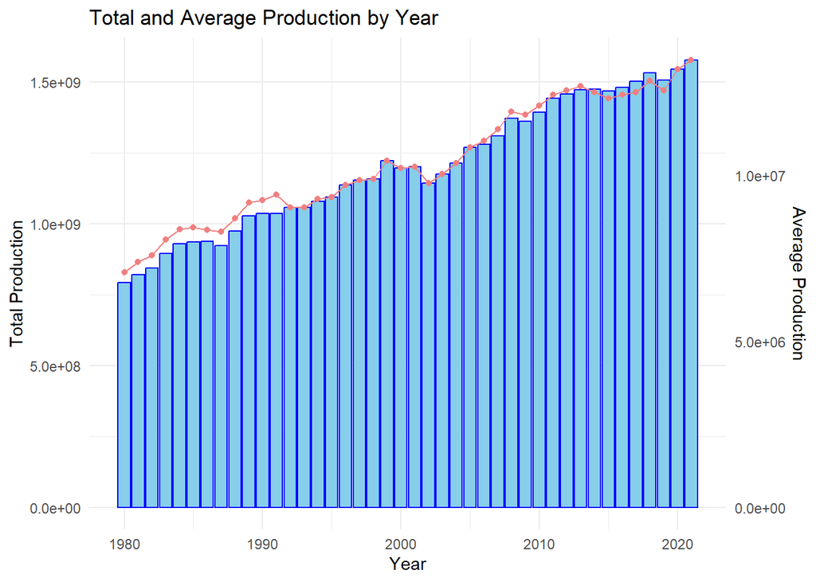

```r
# Combined total and average production by year
combined_prod <- final_trade_df %>%
  group_by(Year) %>%
  summarise(
    total_prod = sum(Production),
    average_prod = mean(Production),
    .groups = 'drop'
  )

# Create a combined plot for total and average production
ggplot() +
  geom_bar(
    data = combined_prod,
    aes(x = Year, y = total_prod),
    stat = "identity",
    fill = "skyblue",
    color = "blue"
  ) +
  # Line plot for average production (secondary y-axis)
  geom_line(data = combined_prod,
            aes(x = Year, y = average_prod * (
              max(combined_prod$total_prod) / max(combined_prod$average_prod)
            )),
            color = "lightcoral") +
  geom_point(
    data = combined_prod,
    aes(x = Year, y = average_prod * (
      max(combined_prod$total_prod) / max(combined_prod$average_prod)
    )),
    color = "lightcoral"
  ) +
  labs(title = "Total and Average Production by Year", x = "Year") +
  theme_minimal() +
  scale_y_continuous(name = "Total Production",
                     sec.axis = sec_axis( ~ . / (
                       max(combined_prod$total_prod) / max(combined_prod$average_prod)
                     ), name = "Average Production"))
```

```r
# Filter data for the last ten years
recent_data <- final_trade_df %>%
  filter(area_type != 'World') %>%
  filter(Year >= max(Year) - 9)

recent_data <- recent_data %>%
  mutate(High_Producer = ifelse(Production > 25000000, "Yes", "No"))


# Identify countries that consistently produced over 25 million tons annually
consistent_high_producers <- recent_data %>%
  group_by(Country) %>%
  filter(all(Production > 25000000)) %>%
  summarise(avg_production = mean(Production)) %>%
  arrange(desc(avg_production))

# Calculate the production threshold for the top quartile over the last ten years
top_quartile_threshold <- recent_data %>%
  summarize(Top_Quartile = quantile(Production, 0.75)) %>%
  pull(Top_Quartile)

# Filter the countries that are in the top quartile and have consistent production
top_quartile_countries <- consistent_high_producers %>%
  filter(avg_production >= top_quartile_threshold)

message("Countries consistently producing over 25 million tons in the last ten years:\n")
print(top_quartile_countries)
```

```
## # A tibble: 7 × 2
##   Country    avg_production
##   <chr>               <dbl>
## 1 China          210478490
## 2 India          169997563
## 3 Indonesia       57204207.
## 4 Bangladesh      53053559.
## 5 Vietnam         43787663.
## 6 Thailand        32561883.
## 7 Myanmar         26757820
```

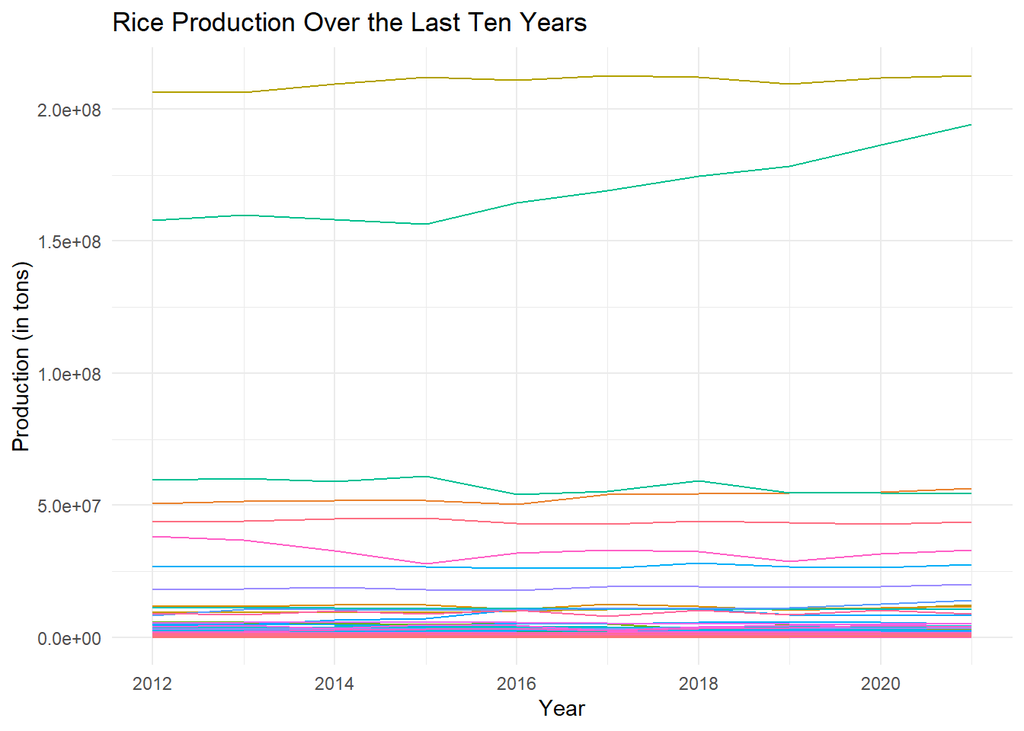

```r
ggplot(recent_data,
       aes(
         x = Year,
         y = Production,
         group = Country,
         color = Country
       )) +
  geom_line() +
  labs(title = "Rice Production Over the Last Ten Years", x = "Year", y = "Production (in tons)") +
  theme_minimal() +
  theme(legend.position = "none")
```

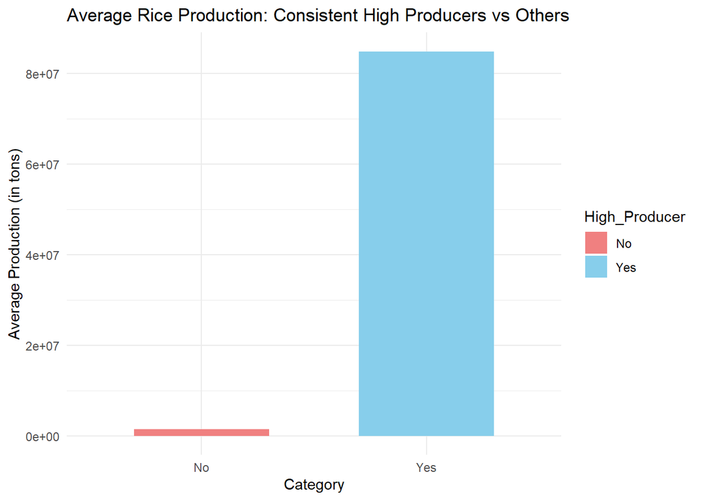

```r
# Create a summary of average production by category
avg_production <- recent_data %>%
  group_by(High_Producer) %>%
  summarize(Average_Production = mean(Production, na.rm = TRUE))

# Bar plot comparing average production of consistent high producers vs others
ggplot(avg_production,
       aes(x = High_Producer, y = Average_Production, fill = High_Producer)) +
  geom_bar(stat = "identity", width = 0.6) +
  labs(title = "Average Rice Production: Consistent High Producers vs Others", x = "Category", y = "Average Production (in tons)") +
  theme_minimal() +
  scale_fill_manual(values = c("Yes" = "skyblue", "No" = "lightcoral"))
```

```r
# Calculate improvement over the last ten years for these countries
improvement_data <- recent_data %>%
  filter(Country %in% top_quartile_countries$Country) %>%
  group_by(Country) %>%
  summarize(Improvement = last(Production) - first(Production)) %>%
  arrange(desc(Improvement))

# Get the countries with the most improvement
most_improved_country <- improvement_data %>%
  filter(Improvement == max(Improvement))  # Identify the country with the most improvement

message("\nCountries showing the most improvement in production:\n")
print(most_improved_country)
```

```
## # A tibble: 1 × 2
##   Country Improvement
##   <chr>         <dbl>
## 1 India      36400000
```

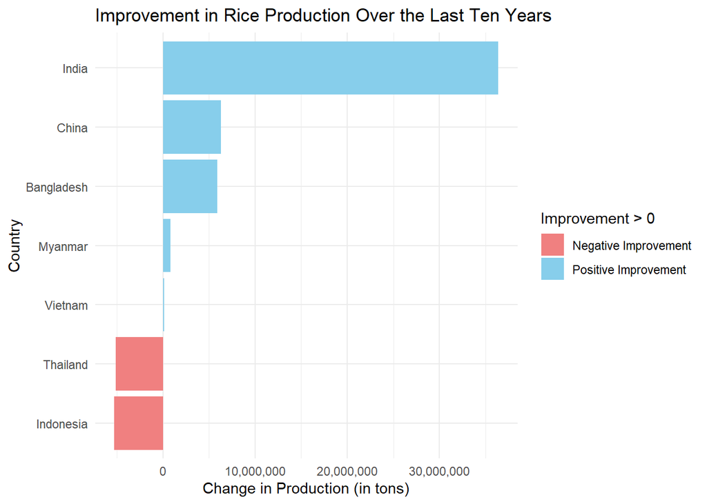

```r
# Visualize the improvement
ggplot(improvement_data,
       aes(
         x = reorder(Country, Improvement),
         y = Improvement,
         fill = Improvement > 0
       )) +
  geom_bar(stat = "identity") +
  coord_flip() +
  labs(title = "Improvement in Rice Production Over the Last Ten Years", x = "Country", y = "Change in Production (in tons)") +
  scale_fill_manual(
    values = c("TRUE" = "skyblue", "FALSE" = "lightcoral"),
    labels = c("TRUE" = "Positive Improvement", "FALSE" = "Negative Improvement")
  ) +
  scale_y_continuous(labels = comma) +
  theme_minimal()
```

```r
## Separate data into high-producers and others
recent_data <- recent_data %>%
  mutate(efficiency = Production / Land_Use,
         production_per_capita = Production / Population) %>%
  filter(
    !is.na(efficiency) &
      !is.na(production_per_capita) &
      efficiency > 0 &
      production_per_capita > 0 & is.finite(efficiency)
  )

high_producers <- recent_data %>%
  filter(Country %in% consistent_high_producers$Country)

non_high_producers <- recent_data %>%
  filter(!Country %in% consistent_high_producers$Country)
```

```r
# Land use efficiency (tons per hectare)
land_use_efficiency <- recent_data %>%
  mutate(efficiency = Production / Land_Use) %>%
  group_by(Country) %>%
  summarise(avg_efficiency = mean(efficiency)) %>%
  arrange(desc(avg_efficiency))

print(land_use_efficiency)
```

```
## # A tibble: 118 × 2
##    Country       avg_efficiency
##    <chr>                  <dbl>
##  1 Australia               9.84
##  2 Egypt                   9.26
##  3 United States           8.46
##  4 Uruguay                 8.31
##  5 Greece                  8.01
##  6 Morocco                 7.85
##  7 Peru                    7.84
##  8 Turkey                  7.83
##  9 Spain                   7.64
## 10 Tajikistan              7.44
## # ℹ 108 more rows
```